## Phân tích các yếu tố ảnh hưởng đến xếp hạng của ứng dụng trên google play store

- Nhóm thực hiện
  - Nguyễn Ngọc Hòa - 18133014
  - Lê Đình Khang - 18133021
  - Võ Thị Thanh Ngân - 18133033
- Thời gian thực hiện: 17-27/1/2021

## Giới thiệu

- Nguồn dữ liệu: https://www.kaggle.com/lava18/google-play-store-apps
- Phân tích tập dữ liệu và rút ra thông tin hữu ích cho những nhà phát triển ứng dụng Android

[figure not shown]

## Tổng quan về dữ liệu

- Cấu trúc của dữ liệu

```
## 'data.frame':    10841 obs. of  13 variables:
##  $ App           : chr  "Photo Editor & Candy Camera & Grid & ScrapBook" "Coloring book moana" "U Launcher Lite – FREE Live Cool Themes, Hide Apps" "Sketch - Draw & Paint" ...
##  $ Category      : chr  "ART_AND_DESIGN" "ART_AND_DESIGN" "ART_AND_DESIGN" "ART_AND_DESIGN" ...
##  $ Rating        : num  4.1 3.9 4.7 4.5 4.3 4.4 3.8 4.1 4.4 4.7 ...
##  $ Reviews       : chr  "159" "967" "87510" "215644" ...
##  $ Size          : chr  "19M" "14M" "8.7M" "25M" ...
##  $ Installs      : chr  "10,000+" "500,000+" "5,000,000+" "50,000,000+" ...
##  $ Type          : chr  "Free" "Free" "Free" "Free" ...
##  $ Price         : chr  "0" "0" "0" "0" ...
##  $ Content.Rating: chr  "Everyone" "Everyone" "Everyone" "Teen" ...
##  $ Genres        : chr  "Art & Design" "Art & Design;Pretend Play" "Art & Design" "Art & Design" ...
##  $ Last.Updated  : chr  "January 7, 2018" "January 15, 2018" "August 1, 2018" "June 8, 2018" ...
##  $ Current.Ver   : chr  "1.0.0" "2.0.0" "1.2.4" "Varies with device" ...
##  $ Android.Ver   : chr  "4.0.3 and up" "4.0.3 and up" "4.0.3 and up" "4.2 and up" ...
```

## Câu hỏi phân tích

- 1. Danh mục(Loại) ứng dụng cửa hàng Google Play nào có xếp hạng cao nhất?
- 2. Liệu xếp hạng của một ứng dụng không bị hạn chế độ tuổi có khác biệt với một ứng dụng bị hạn chế độ tuổi hay không?
- 3. Có sự khác biệt đáng kể về xếp hạng giữa ứng dụng cửa hàng Google Play trả phí hay miễn phí không?

## Hiểu ván đề

- Xem lướt qua dữ liệu
- Trả lời sơ bộ các câu hỏi

## Thiết kế nghiên cứu

- Nghiên cứu này là nghiên cứu quan sát(observational study)
- Phương pháp chọn mẫu:Simple random sampling

## Suy ngẫm về câu hỏi

- Trả lời một cách chủ quan(theo trực giác) các câu hỏi
- Liên hệ thực tế

## Phân tích dữ liệu

- Câu hỏi 1:

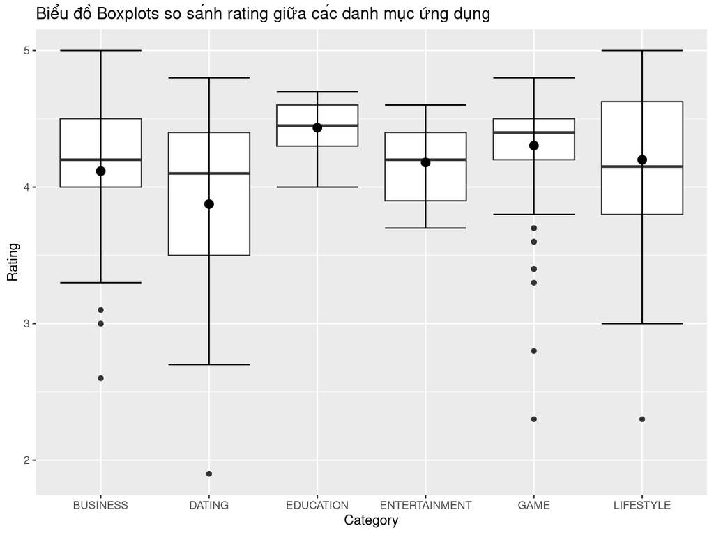

## Phân tích dữ liệu

- Câu hỏi 1:

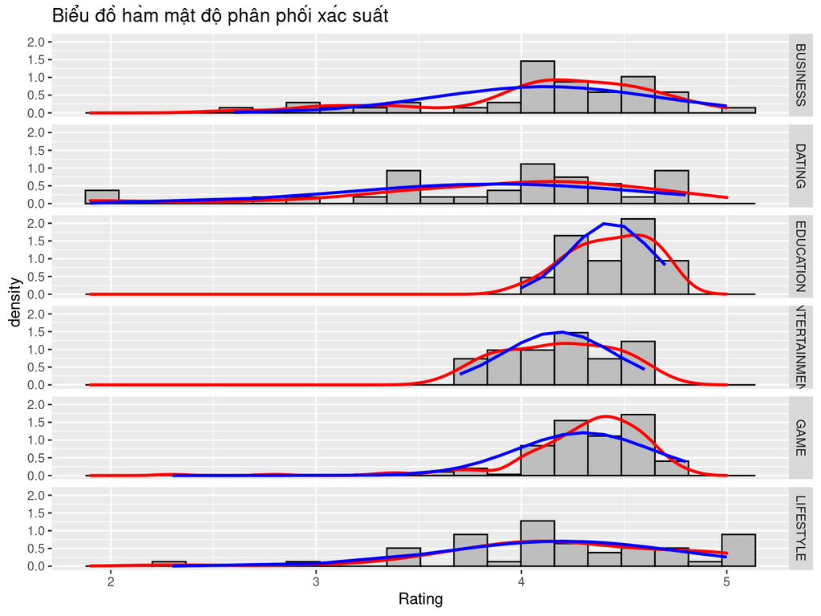

## Phân tích dữ liệu

- Câu hỏi 1:

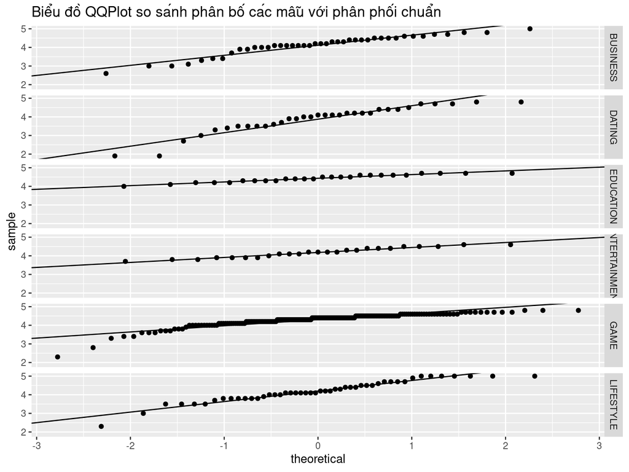

## Phân tích dữ liệu

- Câu hỏi 1:

```
##              Df Sum Sq Mean Sq F value   Pr(>F)
## Category      5   6.87  1.3734   7.252 1.77e-06 ***
## Residuals   350  66.29  0.1894
## ---
## Signif. codes:  0 '***' 0.001 '**' 0.01 '*' 0.05 '.' 0.1 ' ' 1
```

```
##   Tukey multiple comparisons of means
##     95% family-wise confidence level
##
## Fit: aov(formula = Rating ~ Category, data = q1)
##
## $Category
##                                diff          lwr        upr     p adj
## DATING-BUSINESS         -0.24090909 -0.531000866 0.04918268 0.1662106
## EDUCATION-BUSINESS       0.31794872  0.006755921 0.62914151 0.0420021
## ENTERTAINMENT-BUSINESS   0.06333333 -0.251680155 0.37834682 0.9925324
## GAME-BUSINESS            0.18717949 -0.026297010 0.40065598 0.1232011
## LIFESTYLE-BUSINESS       0.08333333 -0.180155606 0.34682227 0.9447610
## EDUCATION-DATING         0.55885781  0.231841991 0.88587363 0.0000219
## ENTERTAINMENT-DATING     0.30424242 -0.026411302 0.63489615 0.0912889
## GAME-DATING              0.42808858  0.192142391 0.66403477 0.0000051
## LIFESTYLE-DATING         0.32424242  0.042240989 0.60624386 0.0137452
## ENTERTAINMENT-EDUCATION -0.25461538 -0.603928432 0.09469766 0.2955536
## GAME-EDUCATION          -0.13076923 -0.392223476 0.13068501 0.7066957
## LIFESTYLE-EDUCATION     -0.23461538 -0.538280543 0.06904977 0.2339009
## GAME-ENTERTAINMENT       0.12384615 -0.142144191 0.38983650 0.7657761
## LIFESTYLE-ENTERTAINMENT  0.02000000 -0.287579372 0.32757937 0.9999688
## LIFESTYLE-GAME          -0.10384615 -0.306191865 0.09849956 0.6832541
```

## Phân tích dữ liệu

- Câu hỏi 2:

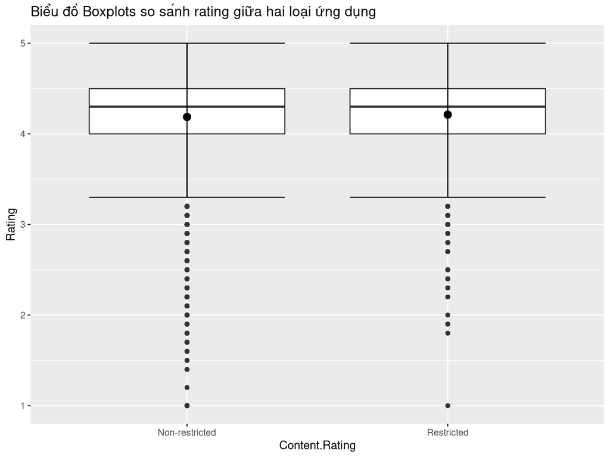

## Phân tích dữ liệu

- Câu hỏi 2:

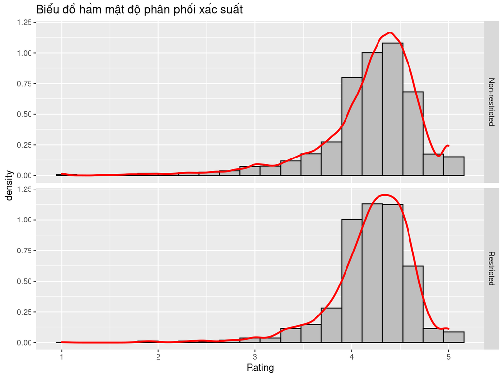

## Phân tích dữ liệu

- Câu hỏi 2:

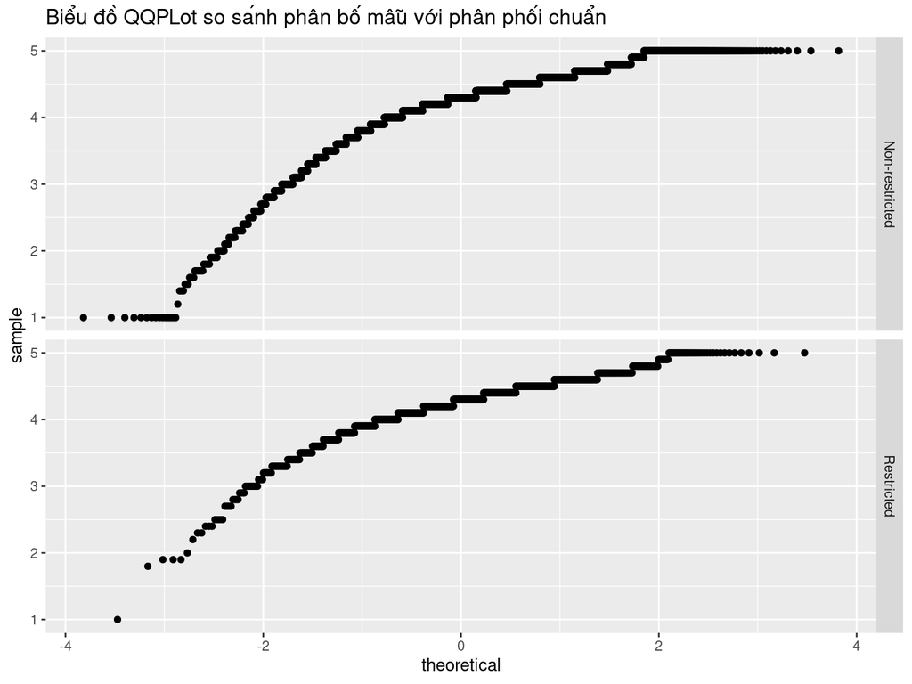

## Phân tích dữ liệu

- Câu hỏi 2:

```
##
##  Welch Two Sample t-test
##
## data:  googlePlay$Rating by googlePlay$Content.Rating
## t = -2.2774, df = 3793.9, p-value = 0.02282
## alternative hypothesis: true difference in means is not equal to 0
## 95 percent confidence interval:
##  -0.048210044 -0.003603837
## sample estimates:
## mean in group Non-restricted     mean in group Restricted
##                     4.186375                     4.212282
```

```
##
##  Welch Two Sample t-test
##
## data:  googlePlay$Rating by googlePlay$Content.Rating
## t = -2.2774, df = 3793.9, p-value = 0.9886
## alternative hypothesis: true difference in means is greater than 0
## 95 percent confidence interval:
##  -0.04462289         Inf
## sample estimates:
## mean in group Non-restricted     mean in group Restricted
##                     4.186375                     4.212282
```

## Phân tích dữ liệu

- Câu hỏi 3:

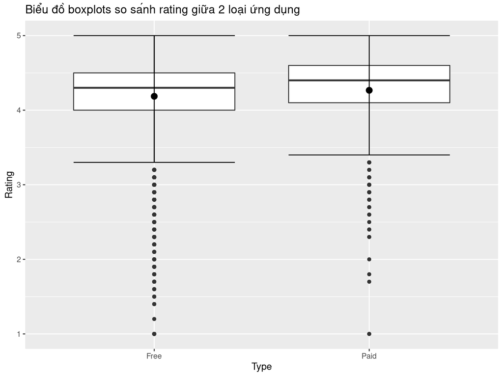

## Phân tích dữ liệu

- Câu hỏi 3:

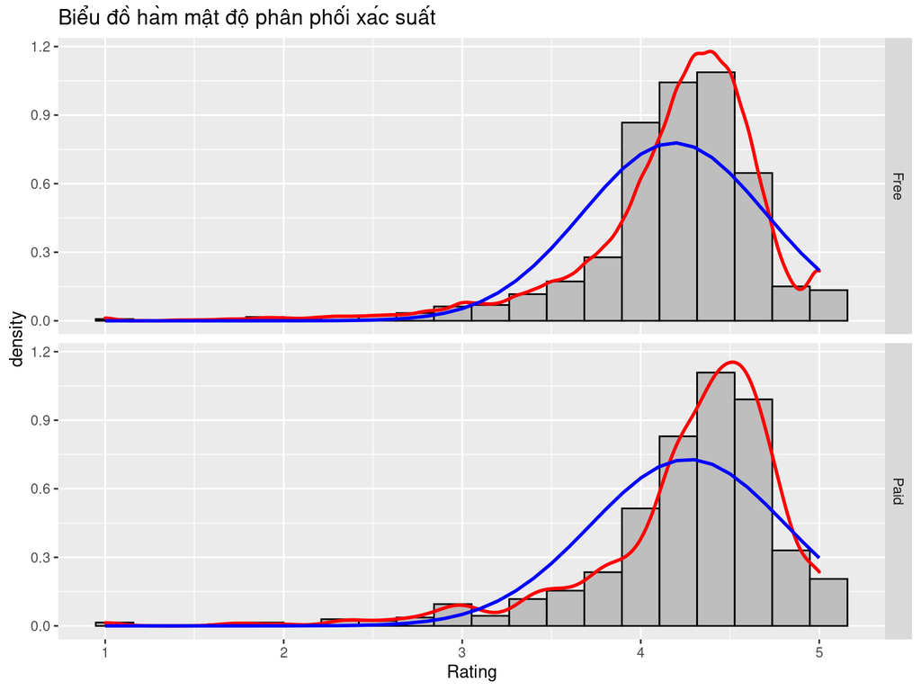

## Phân tích dữ liệu

- Câu hỏi 3:

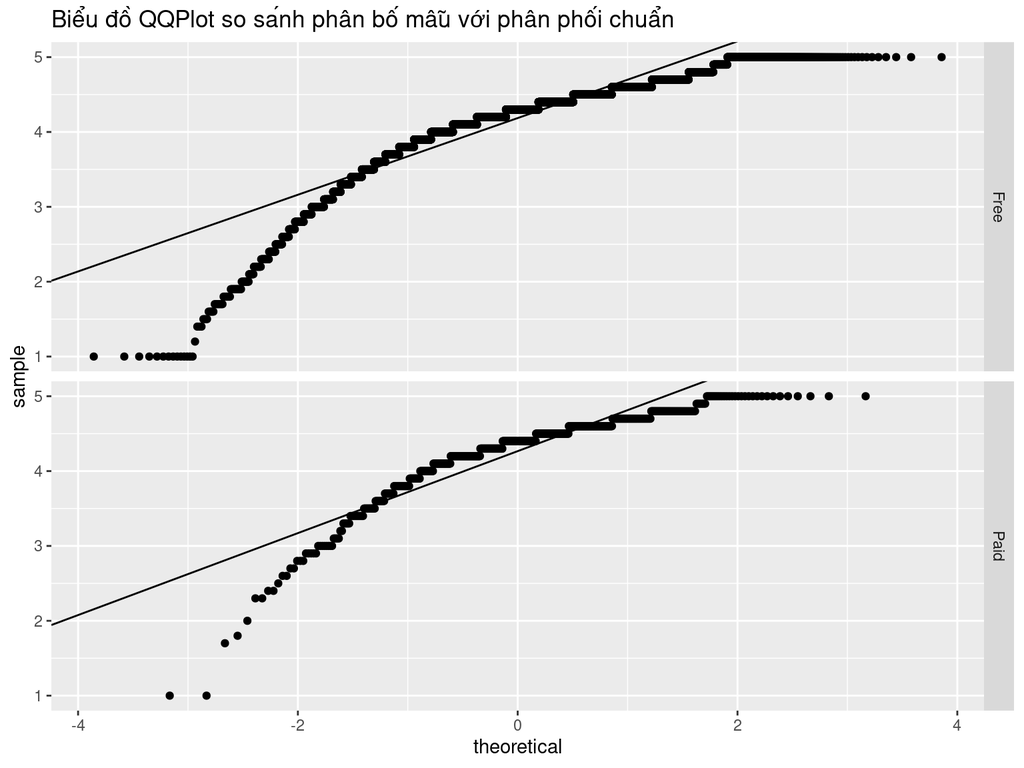

## Phân tích dữ liệu

- Câu hỏi 3:

```
##
##  Welch Two Sample t-test
##
## data:  googlePlay$Rating by googlePlay$Type
## t = -3.62, df = 732.45, p-value = 0.0003149
## alternative hypothesis: true difference in means is not equal to 0
## 95 percent confidence interval:
##  -0.12402263 -0.03680257
## sample estimates:
## mean in group Free mean in group Paid
##           4.186203           4.266615
```

```
##
##  Welch Two Sample t-test
##
## data:  googlePlay$Rating by googlePlay$Type
## t = -3.62, df = 732.45, p-value = 0.0001575
## alternative hypothesis: true difference in means is less than 0
## 95 percent confidence interval:
##         -Inf -0.04382812
## sample estimates:
## mean in group Free mean in group Paid
##           4.186203           4.266615
```

## Kết quả đạt được

- ANOVA F-test cung cấp bằng chứng thống kê để kết luận rằng các danh mục ứng dụng khác nhau có xếp hạng khác nhau và ứng dụng giáo dục có vẻ như là có rating cao nhất.
- two sample t-test chỉ ra rằng có sự khác biệt rõ ràng về rating giữa ứng dụng bị hạn chế độ tuổi và ứng dụng không bị hạn chế độ tuổi. Tuy nhiên phán đoán chủ quan của chúng ta là sai.
- two sample t-test chỉ ra rằng có sự khác biệt rõ ràng về rating giữa ứng dụng trả tiền và miễn phí cụ thể hơn là ứng dụng trả tiền có rating cao hơn. Điều đó hoàn toàn khớp với dự đoán của chúng ta.

## Tổng kết

- Có thể đưa ra một số gợi ý chung cho nhà phát triển về nội dung làm người dùng hài lòng, tuy nhiên việc ứng dụng phát triển ra sao còn tùy thuộc vào xu hướng hiện tại.
- Nhược điểm của bài phân tích:
  - Nghiên cứu này là một nghiên cứu quan sát nên không thể đưa ra các kết luận nhân quả nhằm giúp cho người phát triển hiểu hơn và có thể dự đoán được thị trường tương lai.
  - Việc thu thập dữ liệu của toàn bộ ứng dụng trên CH Play gần như là điều không thể vì thế tính ngẫu nhiên của mẫu không được đảm bảo, rất khó để ta đưa ra kết luận cho toàn bộ các ứng dụng trên CH Play.
  - Thời gian và kiến thức hạn hẹp, không tránh khỏi sai sót trong quá trình thực hiện.